# Анализ пользовательского поведения в мобильном приложении

# Описание проекта

Анализ для крупного интернет-магазина.  
Вместе с отделом маркетинга был подготовлен список гипотез для увеличения выручки.  
Необходимо приоритизировать гипотезы, запустить A/B-тест и проанализировать результаты.

По результатам теста необходимо принять решение. Варианты решений:

1. Остановить тест, зафиксировать победу одной из групп.
2. Остановить тест, зафиксировать отсутствие различий между группами.
3. Продолжить тест.

# Описание данных

1. Данные для первой части

`Hypothesis` — краткое описание гипотезы;  
`Reach` — охват пользователей по 10-балльной шкале;  
`Impact` — влияние на пользователей по 10-балльной шкале;  
`Confidence` — уверенность в гипотезе по 10-балльной шкале;  
`Efforts` — затраты ресурсов на проверку гипотезы по 10-балльной шкале. Чем больше значение Efforts, тем дороже проверка гипотезы.

2. Данные для второй части

Файл `orders`:

`transactionId` — идентификатор заказа;  
`visitorId` — идентификатор пользователя, совершившего заказ;  
`date` — дата, когда был совершён заказ;  
`revenue` — выручка заказа;  
`group` — группа A/B-теста, в которую попал заказ.

Файл `visitors`:

`date` — дата;  
`group` — группа A/B-теста;  
`visitors` — количество пользователей в указанную дату в указанной группе A/B-теста

## Подготовка данных

```python
import pandas as pd
import seaborn as sns
import numpy as np
import matplotlib.pyplot as plt
import scipy.stats as stats
import datetime as dt
```

```python
try:
    visitors = pd.read_csv('visitors.csv')
except:
    visitors = pd.read_csv('/datasets/visitors.csv')

try:
    orders = pd.read_csv('orders.csv')
except:
    orders = pd.read_csv('/datasets/orders.csv')

try:
    hypothesis = pd.read_csv('hypothesis.csv')
except:
    hypothesis = pd.read_csv('/datasets/hypothesis.csv')

display(hypothesis)
display(visitors)
display(orders)
```

|  | Hypothesis | Reach | Impact | Confidence | Efforts |
| --- | --- | --- | --- | --- | --- |
| 0 | Добавить два новых канала привлечения трафика,... | 3 | 10 | 8 | 6 |
| 1 | Запустить собственную службу доставки, что сок... | 2 | 5 | 4 | 10 |
| 2 | Добавить блоки рекомендаций товаров на сайт ин... | 8 | 3 | 7 | 3 |
| 3 | Изменить структура категорий, что увеличит кон... | 8 | 3 | 3 | 8 |
| 4 | Изменить цвет фона главной страницы, чтобы уве... | 3 | 1 | 1 | 1 |
| 5 | Добавить страницу отзывов клиентов о магазине,... | 3 | 2 | 2 | 3 |
| 6 | Показать на главной странице баннеры с актуаль... | 5 | 3 | 8 | 3 |
| 7 | Добавить форму подписки на все основные страни... | 10 | 7 | 8 | 5 |
| 8 | Запустить акцию, дающую скидку на товар в день... | 1 | 9 | 9 | 5 |

|  | date | group | visitors |
| --- | --- | --- | --- |
| 0 | 2019-08-01 | A | 719 |
| 1 | 2019-08-02 | A | 619 |
| 2 | 2019-08-03 | A | 507 |
| 3 | 2019-08-04 | A | 717 |
| 4 | 2019-08-05 | A | 756 |
| ... | ... | ... | ... |
| 57 | 2019-08-27 | B | 720 |
| 58 | 2019-08-28 | B | 654 |
| 59 | 2019-08-29 | B | 531 |
| 60 | 2019-08-30 | B | 490 |
| 61 | 2019-08-31 | B | 718 |

62 rows × 3 columns

|  | transactionId | visitorId | date | revenue | group |
| --- | --- | --- | --- | --- | --- |
| 0 | 3667963787 | 3312258926 | 2019-08-15 | 1650 | B |
| 1 | 2804400009 | 3642806036 | 2019-08-15 | 730 | B |
| 2 | 2961555356 | 4069496402 | 2019-08-15 | 400 | A |
| 3 | 3797467345 | 1196621759 | 2019-08-15 | 9759 | B |
| 4 | 2282983706 | 2322279887 | 2019-08-15 | 2308 | B |
| ... | ... | ... | ... | ... | ... |
| 1192 | 2662137336 | 3733762160 | 2019-08-14 | 6490 | B |
| 1193 | 2203539145 | 370388673 | 2019-08-14 | 3190 | A |
| 1194 | 1807773912 | 573423106 | 2019-08-14 | 10550 | A |
| 1195 | 1947021204 | 1614305549 | 2019-08-14 | 100 | A |
| 1196 | 3936777065 | 2108080724 | 2019-08-15 | 202740 | B |

1197 rows × 5 columns

```python
hypothesis.info()
```

```
<class 'pandas.core.frame.DataFrame'>
RangeIndex: 9 entries, 0 to 8
Data columns (total 5 columns):
 #   Column      Non-Null Count  Dtype
---  ------      --------------  -----
 0   Hypothesis  9 non-null      object
 1   Reach       9 non-null      int64
 2   Impact      9 non-null      int64
 3   Confidence  9 non-null      int64
 4   Efforts     9 non-null      int64
dtypes: int64(4), object(1)
memory usage: 488.0+ bytes
```

```python
visitors.info()
orders.info()
```

```
<class 'pandas.core.frame.DataFrame'>
RangeIndex: 62 entries, 0 to 61
Data columns (total 3 columns):
 #   Column    Non-Null Count  Dtype
---  ------    --------------  -----
 0   date      62 non-null     object
 1   group     62 non-null     object
 2   visitors  62 non-null     int64
dtypes: int64(1), object(2)
memory usage: 1.6+ KB
<class 'pandas.core.frame.DataFrame'>
RangeIndex: 1197 entries, 0 to 1196
Data columns (total 5 columns):
 #   Column         Non-Null Count  Dtype
---  ------         --------------  -----
 0   transactionId  1197 non-null   int64
 1   visitorId      1197 non-null   int64
 2   date           1197 non-null   object
 3   revenue        1197 non-null   int64
 4   group          1197 non-null   object
dtypes: int64(3), object(2)
memory usage: 46.9+ KB
```

```python
print(visitors.duplicated().sum())
print(orders.duplicated().sum())
```

```
0
0
```

```python
# приводим даты
orders['date'] = orders['date'].map(
    lambda x: dt.datetime.strptime(x, '%Y-%m-%d')
)
visitors['date'] = visitors['date'].map(
    lambda x: dt.datetime.strptime(x, '%Y-%m-%d')
)
```

```python
visitors['group'].value_counts()
```

```
B    31
A    31
Name: group, dtype: int64
```

```python
print('Начало теста:', visitors['date'].min())
print('Окончание теста:',visitors['date'].max())
```

```
Начало теста: 2019-08-01 00:00:00
Окончание теста: 2019-08-31 00:00:00
```

Тест длился 31 день, с 2019-08-01 по 2019-08-31, всего было две группы

```python
print('Количество посетителей в группе А:', orders[orders['group'] == 'A']['visitorId'].nunique())
print('Количество посетителей в группе В:',orders[orders['group'] == 'B']['visitorId'].nunique())
```

```
Количество посетителей в группе А: 503
Количество посетителей в группе В: 586
```

```python
grouped = orders.groupby('visitorId')['group'].nunique()
print(grouped[grouped == 2].index.tolist())
print('\nПользователей, попавших в обе группы:', grouped[grouped == 2].shape[0])
```

```
[8300375, 199603092, 232979603, 237748145, 276558944, 351125977, 393266494, 457167155, 471551937, 477780734, 818047933, 963407295, 1230306981, 1294878855, 1316129916, 1333886533, 1404934699, 1602967004, 1614305549, 1648269707, 1668030113, 1738359350, 1801183820, 1959144690, 2038680547, 2044997962, 2…

Пользователей, попавших в обе группы: 58
```

Удалим пользователей, которые по каким-то причинам попали в обе группы, т.к. они могут исказить данные

```python
clean_orders = orders[~orders['visitorId'].isin(grouped[grouped == 2].index.tolist())]

print('Количество посетителей в группе А:', clean_orders[clean_orders['group'] == 'A']['visitorId'].nunique())
print('Количество посетителей в группе В:',clean_orders[clean_orders['group'] == 'B']['visitorId'].nunique())
```

```
Количество посетителей в группе А: 445
Количество посетителей в группе В: 528
```

```python
# немного глупая перезапись, но чтобы было удобнее посмотреть что поменялось
orders = clean_orders
```

Предобработка завершена. Пропущенных значений не обнаружено. Даты приведены к форматы `datetime`.  
Пользователи, которые попали по каким-то причинам в обе группы удалены из таблицы `orders` для более корректного анализа.  
Таблица `visitors` без изменений, поскольку пользователей-дубликатов за все время 58, и на количество пользователей в день это не скажется

## Приоритизация гипотез.

### Приоритизации гипотез. Фреймворк ICE

```python
pd.set_option('display.max_colwidth', None)
hypothesis['ICE'] = round(hypothesis['Impact'] * hypothesis['Confidence'] / hypothesis['Efforts'], 2)
display(hypothesis.sort_values(by = 'ICE', ascending = False))
```

|  | Hypothesis | Reach | Impact | Confidence | Efforts | ICE |
| --- | --- | --- | --- | --- | --- | --- |
| 8 | Запустить акцию, дающую скидку на товар в день рождения | 1 | 9 | 9 | 5 | 16.20 |
| 0 | Добавить два новых канала привлечения трафика, что позволит привлекать на 30% больше пользователей | 3 | 10 | 8 | 6 | 13.33 |
| 7 | Добавить форму подписки на все основные страницы, чтобы собрать базу клиентов для email-рассылок | 10 | 7 | 8 | 5 | 11.20 |
| 6 | Показать на главной странице баннеры с актуальными акциями и распродажами, чтобы увеличить конверсию | 5 | 3 | 8 | 3 | 8.00 |
| 2 | Добавить блоки рекомендаций товаров на сайт интернет магазина, чтобы повысить конверсию и средний чек заказа | 8 | 3 | 7 | 3 | 7.00 |
| 1 | Запустить собственную службу доставки, что сократит срок доставки заказов | 2 | 5 | 4 | 10 | 2.00 |
| 5 | Добавить страницу отзывов клиентов о магазине, что позволит увеличить количество заказов | 3 | 2 | 2 | 3 | 1.33 |
| 3 | Изменить структура категорий, что увеличит конверсию, т.к. пользователи быстрее найдут нужный товар | 8 | 3 | 3 | 8 | 1.12 |
| 4 | Изменить цвет фона главной страницы, чтобы увеличить вовлеченность пользователей | 3 | 1 | 1 | 1 | 1.00 |

#### Вывод

Гипотезы `Запустить акцию, дающую скидку на товар в день рождения`, `Добавить два новых канала привлечения трафика, что позволит привлекать на 30% больше пользователей` и `Добавить форму подписки на все основные страницы, чтобы собрать базу клиентов для email-рассылок` имеют самые высокие показатели ICE, что означает, что они являются наиболее перспективными и должны быть рассмотрены в первую очередь при определении приоритетов тестирования.

Все эти 3 гипотезы имеют наивысший показатель ICE благодаря высоким оценкам в Impact и Confidence. При этом Efforts оценена на уровне среднего уровня. Это может означать, что реализация этой гипотезы потребует некоторых усилий, но она может принести значительное улучшение метрик.

### Приоритизации гипотез. Фреймворк RICE

```python
hypothesis['RICE'] = hypothesis['Reach'] * hypothesis['Impact'] * hypothesis['Confidence'] / hypothesis['Efforts']
display(hypothesis.sort_values(by = 'RICE', ascending = False))
```

|  | Hypothesis | Reach | Impact | Confidence | Efforts | ICE | RICE |
| --- | --- | --- | --- | --- | --- | --- | --- |
| 7 | Добавить форму подписки на все основные страницы, чтобы собрать базу клиентов для email-рассылок | 10 | 7 | 8 | 5 | 11.20 | 112.0 |
| 2 | Добавить блоки рекомендаций товаров на сайт интернет магазина, чтобы повысить конверсию и средний чек заказа | 8 | 3 | 7 | 3 | 7.00 | 56.0 |
| 0 | Добавить два новых канала привлечения трафика, что позволит привлекать на 30% больше пользователей | 3 | 10 | 8 | 6 | 13.33 | 40.0 |
| 6 | Показать на главной странице баннеры с актуальными акциями и распродажами, чтобы увеличить конверсию | 5 | 3 | 8 | 3 | 8.00 | 40.0 |
| 8 | Запустить акцию, дающую скидку на товар в день рождения | 1 | 9 | 9 | 5 | 16.20 | 16.2 |
| 3 | Изменить структура категорий, что увеличит конверсию, т.к. пользователи быстрее найдут нужный товар | 8 | 3 | 3 | 8 | 1.12 | 9.0 |
| 1 | Запустить собственную службу доставки, что сократит срок доставки заказов | 2 | 5 | 4 | 10 | 2.00 | 4.0 |
| 5 | Добавить страницу отзывов клиентов о магазине, что позволит увеличить количество заказов | 3 | 2 | 2 | 3 | 1.33 | 4.0 |
| 4 | Изменить цвет фона главной страницы, чтобы увеличить вовлеченность пользователей | 3 | 1 | 1 | 1 | 1.00 | 3.0 |

#### Вывод

Гипотезы `Добавить форму подписки на все основные страницы, чтобы собрать базу клиентов для email-рассылок`, `Добавить блоки рекомендаций товаров на сайт интернет магазина, чтобы повысить конверсию и средний чек заказа` и `Добавить два новых канала привлечения трафика, что позволит привлекать на 30% больше пользователей` имеют наибольшие показатели RICE, что означает, что они являются наиболее перспективными и должны быть рассмотрены в первую очередь при определении приоритетов тестирования.

Гипотеза `Добавить форму подписки на все основные страницы, чтобы собрать базу клиентов для email-рассылок` поднялась на первое место и имеет наивысший показатель RICE благодаря высокой оценке Reach. Это может означать, что изменения, связанные с этой гипотезой, затронут большое число пользователей и могут привести к значительному улучшению метрик бизнеса.

Гипотеза `Добавить блоки рекомендаций товаров на сайт интернет магазина, чтобы повысить конверсию и средний чек заказа` также сильно поднялась после оценки RICE благодаря высокой оценке Reach. При этом Impact имеет относительно низкую оценку. Это может означать, что ее влияние на метрики бизнеса может быть значительным.

### Вывод

При использовании показателя ICE для приоритизации гипотез наиболее перспективными являются гипотезы `Запустить акцию, дающую скидку на товар в день рождения` и `Добавить два новых канала привлечения трафика, что позволит привлекать на 30% больше пользователей`. Эти гипотезы имеют высокие показатели Impact и Confidence, относительно средний Efforts, но низкий Reach

Однако, при использовании показателя RICE, гипотезы `Добавить форму подписки на все основные страницы, чтобы собрать базу клиентов для email-рассылок` и `Добавить блоки рекомендаций товаров на сайт интернет магазина, чтобы повысить конверсию и средний чек заказа` оказались наиболее перспективными. Это объясняется тем, что они имеют высокие оценки Reach, а также уверенность в том, что изменения повлияют на метрики бизнеса. Гипотеза `Запустить акцию, дающую скидку на товар в день рождения`, которая была высоко оценена по показателю ICE, оказались менее перспективной по показателю RICE, что связано с ее низкой оценкой Reach.

Таким образом, при выборе гипотез для тестирования, я бы рекомендовал использовать показатель RICE, так как он учитывает не только потенциальное влияние на метрики бизнеса, но и охват пользователей, а значит гипотезы `Добавить форму подписки на все основные страницы, чтобы собрать базу клиентов для email-рассылок` и `Добавить блоки рекомендаций товаров на сайт интернет магазина, чтобы повысить конверсию и средний чек заказа` являются наиболее перспективными

## Анализ A/B-теста

### Анализ посещаемости магазина

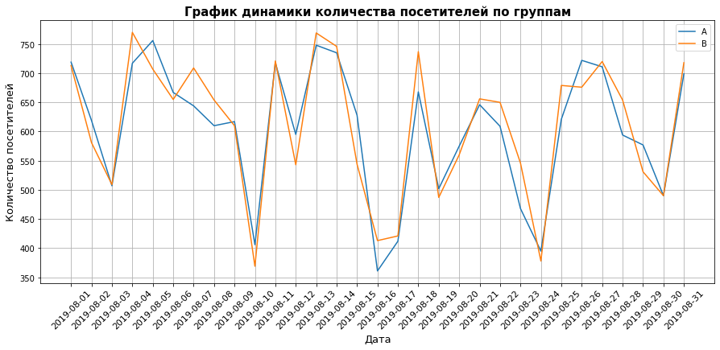

```python
plt.figure(figsize=(15,6))
plt.ticklabel_format(style='plain')
plt.plot(visitors[visitors['group'] == 'A']['date'], visitors[visitors['group'] == 'A']['visitors'], label = 'A')
plt.plot(visitors[visitors['group'] == 'B']['date'], visitors[visitors['group'] == 'B']['visitors'], label = 'B')
plt.legend()
plt.xticks(ticks = visitors[visitors['group'] == 'A']['date'], fontsize = 11, rotation=45)
plt.title('График динамики количества посетителей по группам', fontsize=15, fontweight="bold")
plt.xlabel('Дата', fontsize=13)
plt.ylabel('Количество посетителей', fontsize=13)
plt.grid()
```

Группы имеют крайне схожую динамику посещения: это может означать, что разделение на группы было случайным и хорошо сбалансированным. Однако, динамика посещения подвержена сильным колебаниям и в определенные дни количество посетителей резко снижается, что может указывать на проблемы магазина, не связанные с АВ-тестированием и скорее вызвано внешними факторами, рекомендуется разобраться в их причинах.

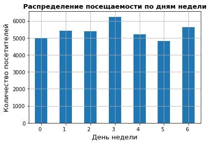

```python
visitors['weekday'] = visitors['date'].dt.weekday
visitors.groupby('weekday').agg({'visitors':'sum'}).plot(kind = 'bar', grid = True, legend = None)
plt.xticks(rotation=0, horizontalalignment='right')
plt.title('Распределение посещаемости по дням недели', fontsize=13, fontweight="bold")
plt.xlabel('День недели', fontsize=13)
plt.ylabel('Количество посетителей', fontsize=13)
plt.show()
```

Распределение посещений по дням недели довольно равномерно и не указывает на какие-либо проблемы. По Субботам посещений меньше из-за покупательского поведения целевой группы магазина, зато по Четвергам количество посещений возрастает (вероятно, хотят заказать товары и получить их в выходные дни), что открывает возможности для роста бизнеса.

### Построение графика кумулятивной выручки по группам

```python
# делаем заказы и выручку по дням
ordersADaily = (
    orders[orders['group'] == 'A'][['date', 'transactionId', 'visitorId', 'revenue']]
    .groupby('date', as_index=False)
    .agg({'transactionId': pd.Series.nunique, 'revenue': 'sum'})
)
ordersADaily.columns = ['date', 'ordersPerDateA', 'revenuePerDateA']

ordersBDaily = (
    orders[orders['group'] == 'B'][['date', 'transactionId', 'visitorId', 'revenue']]
    .groupby('date', as_index=False)
    .agg({'transactionId': pd.Series.nunique, 'revenue': 'sum'})
)
ordersBDaily.columns = ['date', 'ordersPerDateB', 'revenuePerDateB']
```

```python
# делаем заказы и выручку куммулятивно
ordersACummulative = ordersADaily.apply(
    lambda x: ordersADaily[ordersADaily['date'] <= x['date']].agg(
        {'date': 'max', 'ordersPerDateA': 'sum', 'revenuePerDateA': 'sum'}
    ),
    axis=1,
).sort_values(by=['date'])
ordersACummulative.columns = [
    'date',
    'ordersCummulativeA',
    'revenueCummulativeA',
]


ordersBCummulative = ordersBDaily.apply(
    lambda x: ordersBDaily[ordersBDaily['date'] <= x['date']].agg(
        {'date': 'max', 'ordersPerDateB': 'sum', 'revenuePerDateB': 'sum'}
    ),
    axis=1,
).sort_values(by=['date'])
ordersBCummulative.columns = [
    'date',
    'ordersCummulativeB',
    'revenueCummulativeB',
]
```

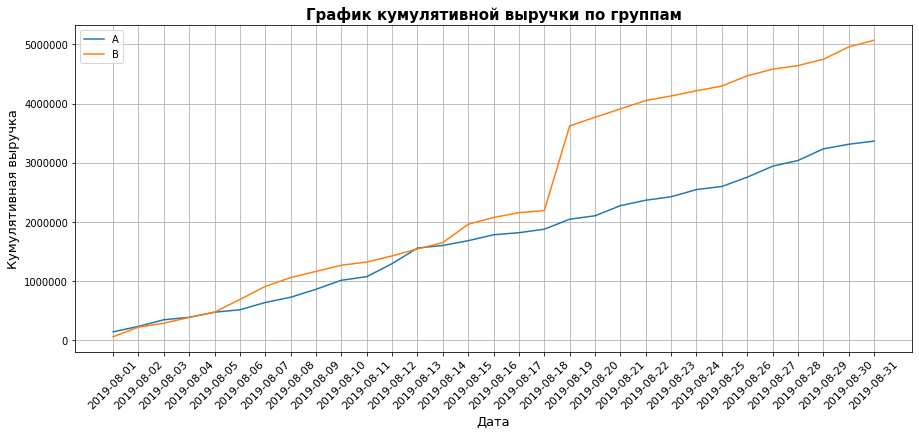

```python
# строим график
plt.figure(figsize=(15,6))
plt.ticklabel_format(style='plain')
plt.plot(ordersACummulative['date'], ordersACummulative['revenueCummulativeA'], label = 'A')
plt.plot(ordersBCummulative['date'], ordersBCummulative['revenueCummulativeB'], label = 'B')
plt.legend()
plt.xticks(ticks = ordersACummulative['date'], fontsize = 11, rotation=45)
plt.title('График кумулятивной выручки по группам', fontsize=15, fontweight="bold")
plt.xlabel('Дата', fontsize=13)
plt.ylabel('Кумулятивная выручка', fontsize=13)
plt.grid()
```

#### Вывод

На графике кумулятивной выручки по группам видно, что начиная с первой недели тестирования группа В опережает группу А по суммарной выручке. В течение первых двух недель тестирования графики выручки для обеих групп имели схожий характер, но начиная с 3-й недели группа В пошла вверх более быстрыми темпами и увеличила свой отрыв. Также, на графике заметен резкий скачок кумулятивной выручки у группы В с 17 по 18 дни тестирования, возможно, это вызвано всплеском заказов в этот период времени (конверсией) или резким увеличением среднего чека заказа.  
Для выяснения причин такого скачка необходимо построить и проанализировать графики среднего чека и среднего числа заказов на пользователя, что будет выполнено ниже.

### Построение графика кумулятивного среднего чека по группам

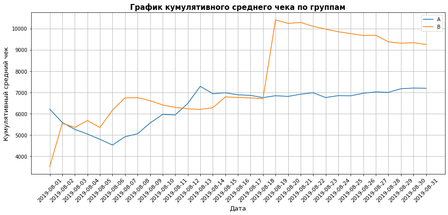

```python
# строим еще график
plt.figure(figsize=(15,6))
plt.plot(ordersACummulative['date'],
         ordersACummulative['revenueCummulativeA'] / ordersACummulative['ordersCummulativeA'],
         label = 'A')

plt.plot(ordersBCummulative['date'],
         ordersBCummulative['revenueCummulativeB'] / ordersBCummulative['ordersCummulativeB'],
         label = 'B')

plt.legend()
plt.xticks(ticks = ordersACummulative['date'], fontsize = 11, rotation=45)
plt.title('График кумулятивного среднего чека по группам', fontsize=15, fontweight="bold")
plt.xlabel('Дата', fontsize=13)
plt.ylabel('Кумулятивный средний чек', fontsize=13)
plt.grid()
```

#### Вывод

На графике кумулятивного среднего чека по группам видно, что в начале тестирования группы были подвержены сильным колебаниям. Однако, начиная с 8-9 дня тестирования, значения стабилизировались. На 18 день группа В показала резкий рост кумулятивного среднего чека, вероятно, группа В получила несколько крупных заказов, что привело к увеличению среднего чека. После этого значение кумулятивного среднего чека у группы В начало плавно снижаться, в то время как у группы А он оставался более стабильным.  
В целом, график кумулятивного среднего чека по группам подтверждает предыдущее предположение о том, что группа В показывает более высокую выручку, чем группа А. Однако, необходимо учитывать, что средний чек является чувствительной метрикой, которая может меняться под влиянием различных факторов.

### Построение графика относительного изменения кумулятивного среднего чека группы B к группе A

```python
# объединяем в дф для следубщего графика
mergedCummulativeRevenue = ordersACummulative.merge(ordersBCummulative, on = 'date', how = 'left')
```

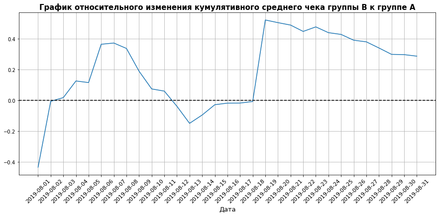

```python
# строим график
plt.figure(figsize=(15,6))
plt.plot(mergedCummulativeRevenue['date'],
         (mergedCummulativeRevenue['revenueCummulativeB'] / mergedCummulativeRevenue['ordersCummulativeB'])
         / (mergedCummulativeRevenue['revenueCummulativeA'] / mergedCummulativeRevenue['ordersCummulativeA']) - 1)
plt.axhline(y=0, color='black', linestyle='--')
plt.xticks(ticks = ordersACummulative['date'], fontsize = 11, rotation=45)
plt.title('График относительного изменения кумулятивного среднего чека группы B к группе A', fontsize=15, fontweight="bold")
plt.xlabel('Дата', fontsize=13)
plt.grid()
```

#### Вывод

На графике относительного изменения кумулятивного среднего чека группы В к группе А видно, что в начале тестирования отношение кумулятивного среднего чека группы В к группе А было колеблющимся вокруг среднего значения, но затем произошло резкое увеличение, после которого отношение стало колебаться вокруг более высокого значения.  
Это подтверждает вывод, сделанный по графику кумулятивного среднего чека, что группа В показывает более высокую выручку, чем группа А, начиная с 18 дня тестирования. В данном случае график относительного изменения кумулятивного среднего чека позволяет более наглядно оценить разницу в среднем чеке между группами.  
Однако, как и в предыдущем случае, изменение среднего чека может быть вызвано различными факторами, поэтому для более точного анализа необходимо провести дополнительные исследования.

### Построение графика кумулятивного среднего количества заказов на посетителя по группам

```python
# деляаем кумулятивных посетителей А
visitorsA = visitors[visitors['group'] == 'A']

visitorsCummulativeA = visitorsA.apply(
    lambda x: visitorsA[visitorsA['date'] <= x['date']].agg(
        {'date': 'max', 'visitors' : 'sum'}), axis = 1).sort_values(by = ['date'])
visitorsCummulativeA.columns = ['date', 'visitorsCummulativeA']

# деляаем кумулятивных посетителей В
visitorsB = visitors[visitors['group'] == 'B']

visitorsCummulativeB = visitorsB.apply(
    lambda x: visitorsB[visitorsB['date'] <= x['date']].agg(
        {'date': 'max', 'visitors' : 'sum'}), axis = 1).sort_values(by = ['date'])
visitorsCummulativeB.columns = ['date', 'visitorsCummulativeB']

# объединяем
visitorsCummulativeMerged = visitorsCummulativeA.merge(visitorsCummulativeB, on = 'date', how = 'left')
```

```python
# собираем в большую таблицу
dataCummulativeMerged = mergedCummulativeRevenue.merge(visitorsCummulativeMerged, on = 'date', how = 'left')
```

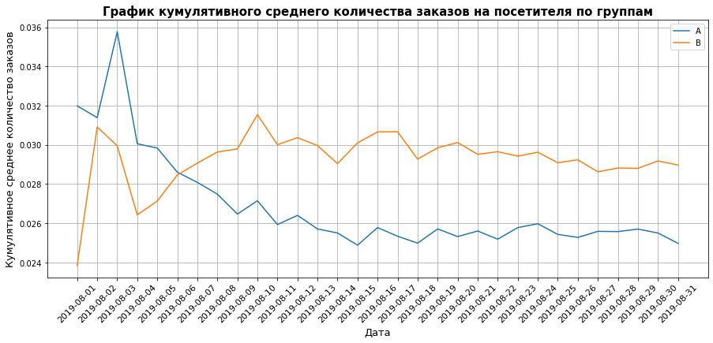

```python
# теперь смотрим среднее кол-во заказов на пользователя и делаем графики
plt.figure(figsize=(15,6))
plt.plot(dataCummulativeMerged['date'],
         dataCummulativeMerged['ordersCummulativeA'] / dataCummulativeMerged['visitorsCummulativeA'],
         label = 'A')

plt.plot(dataCummulativeMerged['date'],
         dataCummulativeMerged['ordersCummulativeB'] / dataCummulativeMerged['visitorsCummulativeB'],
         label = 'B')

plt.legend()
plt.xticks(ticks = dataCummulativeMerged['date'], fontsize = 11, rotation=45)
plt.title('График кумулятивного среднего количества заказов на посетителя по группам', fontsize=15, fontweight="bold")
plt.xlabel('Дата', fontsize=13)
plt.ylabel('Кумулятивное среднее количество заказов', fontsize=13)
plt.grid()
```

### Построение графика относительного изменения кумулятивного среднего количества заказов на посетителя группы B к группе A

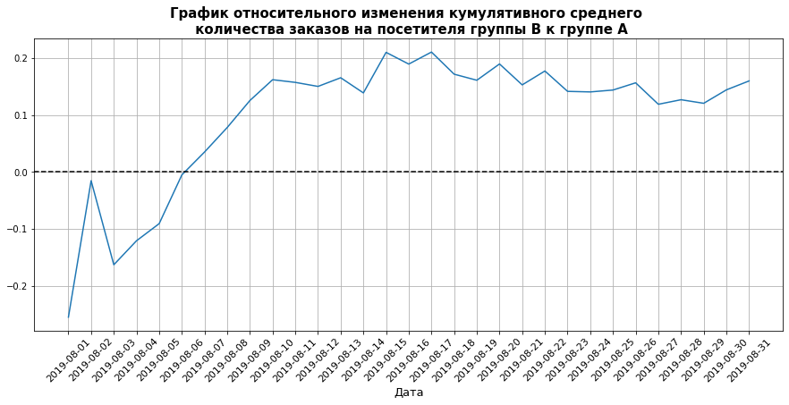

```python
# теперь смотрим ОТНОСИТЕЛЬНОЕ среднее кол-во заказов на пользователя и делаем графики
plt.figure(figsize=(15,6))
plt.plot(dataCummulativeMerged['date'],
         (dataCummulativeMerged['ordersCummulativeB'] / dataCummulativeMerged['visitorsCummulativeB'])
         / (dataCummulativeMerged['ordersCummulativeA'] / dataCummulativeMerged['visitorsCummulativeA']) - 1)
plt.axhline(y=0, color='black', linestyle='--')
plt.xticks(ticks = dataCummulativeMerged['date'], fontsize = 11, rotation=45)
plt.title('График относительного изменения кумулятивного среднего \n количества заказов на посетителя группы B к группе A', fontsize=15, fontweight="bold")
plt.xlabel('Дата', fontsize=13)
plt.grid()
```

### Построение точечного графика количества заказов по пользователям

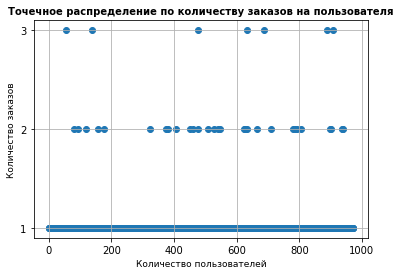

```python
# сгруппируем по кол-ву заказаов на пользователя
ordersByUser = (orders.groupby('visitorId', as_index = False)
                .agg({'transactionId':'nunique'}))

# Постройте точечный график количества заказов по пользователям.
x_values = pd.Series(range(0,len(ordersByUser)))

plt.scatter(x_values, ordersByUser['transactionId'])
plt.locator_params(axis= 'y', nbins=3)
plt.title('Точечное распределение по количеству заказов на пользователя', fontsize=10, fontweight="bold")
plt.ylabel('Количество заказов', fontsize=9)
plt.xlabel('Количество пользователей', fontsize=9)
plt.grid()
```

#### Вывод

График показывает, что подавляющее большинство пользователей делает только один заказ, что говорит о том, что большинство посетителей интернет-магазина являются единоразовыми покупателями.  
Совсем немного пользователей делают два заказа, а еще меньше три заказа. Учитывая, что только небольшое количество пользователей делают более 1 заказа за период тестирования, вероятно, стоит исследовать как можно увеличить количество повторных покупок.  
Для наглядности посчитаем перцентили количества заказов

### Расчет 95-ого и 99-ого перцентилей количества заказов на пользователя

```python
print('95-й перцентиль:', np.percentile(ordersByUser['transactionId'], 95))
print('99-й перцентиль:', np.percentile(ordersByUser['transactionId'], 99))
abnormal_orders = np.percentile(ordersByUser['transactionId'], 99)
```

```
95-й перцентиль: 1.0
99-й перцентиль: 2.0
```

### Построение точечного графика стоимостей заказов

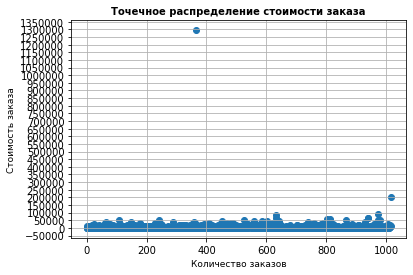

```python
x_values = pd.Series(range(0,len(orders)))
plt.ticklabel_format(style='plain')
plt.scatter(x_values, orders['revenue'])
plt.locator_params(axis= 'y', nbins=30)
plt.title('Точечное распределение стоимости заказа', fontsize=10, fontweight="bold")
plt.ylabel('Стоимость заказа', fontsize=9)
plt.xlabel('Количество заказов', fontsize=9)
plt.grid()
```

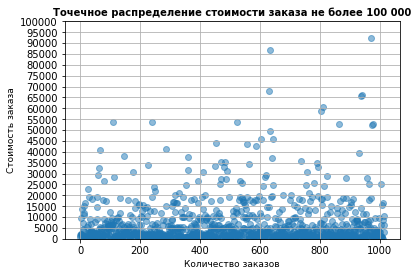

```python
x_values = pd.Series(range(0,len(orders)))
plt.ticklabel_format(style='plain')
plt.scatter(x_values, orders['revenue'], alpha = 0.5)
plt.locator_params(axis= 'y', nbins=30)
plt.title('Точечное распределение стоимости заказа не более 100 000', fontsize=10, fontweight="bold")
plt.ylabel('Стоимость заказа', fontsize=9)
plt.xlabel('Количество заказов', fontsize=9)
plt.grid()
plt.ylim([0, 100000])
plt.show()
```

#### Вывод

Из графика можно сделать вывод, что большинство заказов обходится менее чем в 30 000 рублей. Однако есть очень дорогие заказы, что является выбросами. Для наглядности расчитаем перцентили

### Расчет 95-ого и 99-ого перцентилей стоимости заказов

```python
print('95-й перцентиль:', round(np.percentile(orders['revenue'], 95)))
print('99-й перцентиль:', round(np.percentile(orders['revenue'], 99)))
abnormal_revenue = np.percentile(orders['revenue'], 97)
```

```
95-й перцентиль: 26785
99-й перцентиль: 53904
```

### Расчет статистической значимости различий в среднем количестве заказов на посетителя между группами по «сырым» данным

Для расчета статистической значимости примем нулевую и альтернтивную гипотезы:  
Н0: Статистически значимых различий в среднем количестве заказов на посетителя между группами нет.  
Н1: Существуют статистически значимые различия в среднем количестве заказов на посетителя между группами.

```python
# сгруппируем по кол-ву заказов на пользователя в группе А
ordersByUsersA = (
    orders[orders['group'] == 'A']
    .groupby('visitorId', as_index=False)
    .agg({'transactionId': 'nunique'})
)
ordersByUsersA.columns = ['visitorId', 'transactions']

# сгруппируем по кол-ву заказов на пользователя в группе В
ordersByUsersB = (
    orders[orders['group'] == 'B']
    .groupby('visitorId', as_index=False)
    .agg({'transactionId': 'nunique'})
)
ordersByUsersB.columns = ['visitorId', 'transactions']
```

```python
# проведем тест уитни-манна
sampleA = pd.concat([ordersByUsersA['transactions'],
                     pd.Series(0,
                               index = np.arange(visitorsA['visitors'].sum() - len(ordersByUsersA['transactions'])),
                               name = 'transactions')], axis = 0)

sampleB = pd.concat([ordersByUsersB['transactions'],
                     pd.Series(0,
                               index = np.arange(visitorsB['visitors'].sum() - len(ordersByUsersB['transactions'])),
                               name = 'transactions')], axis = 0)
```

```python
print("Значение p-value: {0:.3f}".format(stats.mannwhitneyu(sampleA, sampleB)[1]))
print("Относительный прирост группы В к группе А: {0:.3f}".format(sampleB.mean() / sampleA.mean() - 1))
```

```
Значение p-value: 0.011
Относительный прирост группы В к группе А: 0.160
```

#### Вывод

Относительный прирост количества заказов в группе B по сравнению с группой A составляет 16%.  
P-value меньше уровня критической значимости (0.05), нулевую гипотезу можно отвергнуть.  
Это означает, что группа B показывает лучшие результаты по количеству заказов на пользователя по сравнению с группой A, и это различие является статистически значимым.

### Расчет статистической значимости различий в среднем чеке заказа между группами по «сырым» данным

Для расчета статистической значимости примем нулевую и альтернтивную гипотезы:  
Н0: Статистически значимых различий в среднем чеке заказа между группами нет.  
Н1: Существуют статистически значимые различия среднем чеке заказа между группами.

```python
print('Значение p-value: {0:.3f}'.format(stats.mannwhitneyu(orders[orders['group'] == 'A']['revenue'],
                                          orders[orders['group'] == 'B']['revenue'])[1]))

print('Относительный прирост группы В к группе А: {0:.3f}'.format(orders[orders['group']=='B']['revenue'].mean() /
                       orders[orders['group']=='A']['revenue'].mean()-1))
```

```
Значение p-value: 0.829
Относительный прирост группы В к группе А: 0.287
```

#### Вывод

Относительный прирост среднего чека группы B к группе A составил 28.7%.  
P-value больше уровня критической значимости (0.05), нулевую гипотезу не отвергаем.  
Это означает, что группа B показывает лучшие результаты по среднему чеку заказа по сравнению с группой A, но это не может быть подтверждено статистически, а следовательно такое различие было получено случайно.

### Расчет статистической значимости различий в среднем количестве заказов на посетителя между группами по «очищенным» данным

Гипотезы аналогичны расчетам по "сырым" данным:  
Н0: Статистически значимых различий в среднем количестве заказов на посетителя между группами нет.  
Н1: Существуют статистически значимые различия в среднем количестве заказов на посетителя между группами.

```python
# приступим к очистке данных
# отсеим пользователей с большим кол-вом заказов

usersWithManyOrders = pd.concat(
    [
        ordersByUsersA[ordersByUsersA['transactions'] > abnormal_orders]['visitorId'],
        ordersByUsersB[ordersByUsersB['transactions'] > abnormal_orders]['visitorId'],
    ],
    axis=0,
)
```

```python
# отсеим пользователей с дорогими заказами

usersWithExpensiveOrders = orders[orders['revenue'] > abnormal_revenue]['visitorId']
abnormalUsers = (
    pd.concat([usersWithManyOrders, usersWithExpensiveOrders], axis=0)
    .drop_duplicates()
    .sort_values()
)
```

```python
# объединим пользоваталей с многими заказами с пользователями с дорогими заказами
abnormalUsers = (
    pd.concat([usersWithManyOrders, usersWithExpensiveOrders], axis=0)
    .drop_duplicates()
    .sort_values()
)

print('Количество аномальных пользователей:', abnormalUsers.shape[0])
```

```
Количество аномальных пользователей: 38
```

```python
# сделаем отфильтрованны сэмлы, где не будет аномальных пользователей

sampleAFiltered = pd.concat([ordersByUsersA[np.logical_not(
            ordersByUsersA['visitorId'].isin(abnormalUsers))]['transactions'],
                     pd.Series(0,
                               index = np.arange(visitorsA['visitors'].sum() - len(ordersByUsersA['transactions'])),
                               name = 'transactions')], axis = 0)

sampleBFiltered = pd.concat([ordersByUsersB[np.logical_not(
            ordersByUsersB['visitorId'].isin(abnormalUsers))]['transactions'],
                     pd.Series(0,
                               index = np.arange(visitorsB['visitors'].sum() - len(ordersByUsersB['transactions'])),
                               name = 'transactions')], axis = 0)
```

```python
print("Значение p-value: {0:.3f}".format(stats.mannwhitneyu(sampleAFiltered, sampleBFiltered)[1]))

print("Относительный прирост группы В к группе А: {0:.3f}".format(sampleBFiltered.mean() / sampleAFiltered.mean() - 1))
```

```
Значение p-value: 0.006
Относительный прирост группы В к группе А: 0.197
```

#### Вывод

P-value меньше уровня критической значимости (0.05), нулевую гипотезу по-прежнему можно отвергнуть.  
Исключение аномальных пользователей повлияло на результат следующим образом: относительный прирост количества заказов в группе B по сравнению с группой A вырос с 16% до 19.7%.  
Таким образом, можно сделать вывод, что группа B статистически значимо лучше группы A по среднему количеству заказов на пользователя.

### Расчет статистической значимости различий в среднем чеке заказа между группами по «очищенным» данным

```python
print('Значение p-value: {0:.3f}'.format(stats.mannwhitneyu(
            orders[
                np.logical_and(
                    orders['group'] == 'A',
                    np.logical_not(orders['visitorId'].isin(abnormalUsers)),)]['revenue'],
                orders[
                np.logical_and(
                    orders['group'] == 'B',
                    np.logical_not(orders['visitorId'].isin(abnormalUsers)),)]['revenue'],)[1]))


print('Относительный прирост группы В к группе А: {0:.3f}'.format(orders[
                        np.logical_and(
                        orders['group'] == 'B',
                        np.logical_not(orders['visitorId'].isin(abnormalUsers)))]['revenue'].mean() /
                           orders[
                                np.logical_and(
                                orders['group'] == 'A',
                                np.logical_not(orders['visitorId'].isin(abnormalUsers)))]['revenue'].mean()-1))
```

```
Значение p-value: 0.918
Относительный прирост группы В к группе А: 0.016
```

## Вывод и принятие решения по результатам А/В-теста

Итак, с учетом всех проведенных анализов и проверок гипотез, можно сделать следующие выводы:

Группа B в целом показывает лучшие результаты по кумулятивной выручке и кумулятивному среднему чеку, однако различия не являются статистически значимыми.

Средний чек заказа в группе B в течение теста был несколько выше, чем в группе A, но эта разница также не является статистически значимой.

Среднее количество заказов на пользователя в группе B статистически значимо выше, чем в группе A, и разница составляет 19,7% после очистки данных от выбросов.

В целом, проведенное A/B тестирование показало, что группа B имеет лучшие показатели в сравнении с группой A по среднему чеку и среднему количеству заказов на посетителя. Однако, различия в среднем чеке по очищенным данным статистически незначимы, что может говорить о том, что различия случайны и могут исчезнуть при дальнейшем тестировании.

С учетом вышесказанного, можно принять решение остановить тест и зафиксировать победу группы B по среднему количеству заказов на посетителя. Однако, для более точных результатов и уверенности в принятом решении, желательно продолжить тестирование, например, на более длительный период времени, чтобы убедиться в стабильности полученных результатов. Также можно провести дополнительное исследование, чтобы понять, почему группа B показывает лучшие результаты и на основе этого сформировать новые гипотезы для дальнейшего тестирования.

Также рекомендуется провести работу над ошибками и в дальнейших тестированиях не допускать попадания одного пользователя в несколько групп сразу, а также разобраться с причинам резких снижений посещаемости в определенные дни, чтобы в дальнейшем не допускать такого